# Spotligt of ENSG00000163932.9

# 1 Setup

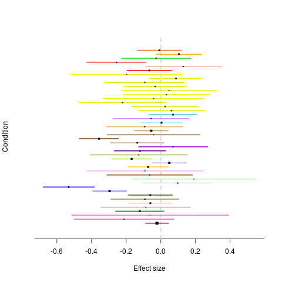

```r
highlight.snp.df <- read.table(paste0('../../', '../motif_analysis/output/skin_second_try/report//summary_table.txt'), header = T, sep = '\t')
rdss <- strsplit('output/skin_motif_snp/Skin_Sun_Exposed_Lower_leg/fine-map__susie/ENSG00000163932.9.rds,output/skin_motif_snp/Skin_Not_Sum_Exposed_Suprapubic/fine-map__susie/ENSG00000163932.9.rds,output/skin_motif_snp-more_tissue/Artery_Aorta/fine-map__susie/ENSG00000163932.9.rds,output/skin_motif_snp-more_tissue/Esophagus_Mucosa/fine-map__susie/ENSG00000163932.9.rds', ',')[[1]]
gene <- 'ENSG00000163932.9'
motif_prefix <- paste0('../../', '../motif_analysis/output/skin_second_try/report//motif_logo/')
cols <- c('gene_name', 'motif_snp', 'r', 'motif_id', 'motif_name', 'motif_qval', 'motif_snp.pos', 'motif.length', 'strand', 'tissue', 'pip')
tissue <- basename(dirname(dirname(rdss[1])))
highlight.snp <- highlight.snp.df[highlight.snp.df$ensembl_gene_id == str_match(gene, '([A-Za-z0-9]+).[A-Za-z0-9]+')[, 2] & highlight.snp.df$tissue == tissue, ]
idx <- highlight.snp$idx[1]
mash <- paste0('../../', '../motif_analysis/output/skin_second_try/report//mash_plot/', '/', 'mash__idx', idx, '.png')
cat('
', paste0('![](', mash, ')'), '
', '
')
```

```r
highlight.snp.df$strand <- as.character(highlight.snp.df$strand)
highlight.snp.df$strand[highlight.snp.df$strand == '-'] <- 'negative'
highlight.snp.df$strand[highlight.snp.df$strand == '+'] <- 'positive'
```

# 2 Results

```r
df.purity <- data.frame()
hitted <- data.frame()
mytheme <- gridExtra::ttheme_default(
    core = list(fg_params=list(cex = .7)),
    colhead = list(fg_params=list(cex = .7)),
    rowhead = list(fg_params=list(cex = .7)))
for(rds in rdss) {
  tissue <- basename(dirname(dirname(rds)))
  out <- readRDS(paste0('../../', rds))
  cs0 <- susieR::susie_get_CS(out$fitted, t(data.matrix(out$X[, -ncol(out$X)])), min_abs_corr = 0)
  if(nrow(cs0$purity) > 0) {
    cs0$purity <- round(cs0$purity, digits = 2)
    cs0$purity$tissue <- tissue
  }
  a <- cs0$purity
  if(nrow(a) == 0) {
    a <- data.frame(NA)
  }
  tb0 <- tableGrob(a, widths=unit(rep(1/ncol(a), ncol(a)),"npc")-unit(1,"line"), theme = mytheme)
  cs <- susieR::susie_get_CS(out$fitted, t(data.matrix(out$X[, -ncol(out$X)])), coverage = 0.9)
  if(nrow(cs$purity) > 0) {
    cs$purity$tissue <- tissue
    df.purity <- rbind(df.purity, cs$purity)
  }
  pip <- susieR::susie_get_PIP(out$fitted, cs$cs_index)
  coordinate <- as.numeric(str_match(out$X$SNP_ID, '[0-9]+_([0-9]+)_[A-Za-z]+_[A-Za-z]+_[A-Za-z0-9]+')[, 2])
  df <- data.frame(coordinate = coordinate, pip = pip)
  df$cs <- -1
  if(length(cs$cs_index) != 0) {
    for(i in 1 : length(cs$cs_index)) {
      df$cs[cs$cs[[i]]] <- cs$cs_index[i]
    }
  }
  highlight.snp <- highlight.snp.df[highlight.snp.df$ensembl_gene_id == str_match(gene, '([A-Za-z0-9]+).[A-Za-z0-9]+')[, 2] & highlight.snp.df$tissue == tissue, ]
  leading.snp <- as.numeric(str_match(highlight.snp$leading_eqtl[1], '[0-9]+_([0-9]+)_[A-Za-z]+_[A-Za-z]+_[A-Za-z0-9]+')[, 2])
  candidate.snp <- as.numeric(str_match(highlight.snp$motif_snp, '[0-9]+_([0-9]+)_[A-Za-z]+_[A-Za-z]+_[A-Za-z0-9]+')[, 2])
  df$type <- 'No'
  df$type[df$coordinate %in% candidate.snp] <- 'Motif SNP'
  df$type[df$coordinate %in% leading.snp] <- 'Leading SNP'
  df$cs <- factor(df$cs)
  p <- ggplot(df)
  p <- p + ggtitle(paste0(tissue, '
 PIP (red line: leadingSNP; blue line: candidateSNP)'))
  p <- p + geom_vline(xintercept = candidate.snp, color = 'blue')
  p <- p + geom_vline(xintercept = leading.snp, color = 'red', linetype = 2) + theme(legend.position = "bottom")
  p <- p + geom_point(aes(x = coordinate, y = pip, color = cs, shape = type), size = 3)
  highlight.snp$pip <- pip[match(as.numeric(str_match(highlight.snp$motif_snp, '[0-9]+_([0-9]+)_[A-Za-z]+_[A-Za-z]+_[A-Za-z0-9]+')[, 2]), coordinate)]
  hitted.sub <- highlight.snp[candidate.snp %in% coordinate[unlist(cs$cs)], ]
  hitted <- rbind(hitted, hitted.sub)
  e <- plot_grid(plotlist = list(p, tb0), ncol = 1, rel_heights = c(3/4, 1/4))
  cat('##', tissue, '
', '
')
  subchunkify(e, fig_asp = .8)
  cat('
', '
')
  if(nrow(hitted.sub) != 0) {
    hitted.sub$motif_logo <- paste0('![](', motif_prefix, '/', hitted.sub$dbname, '__', hitted.sub$motif_id, '.png', ')')
    hitted.sub <- hitted.sub[, c(cols, 'motif_logo')]
    print(hitted.sub %>% kable(format = "html", col.names = colnames(hitted.sub)) %>%
    kable_styling() %>%
    kableExtra::scroll_box(width = "100%", height = "500px"))
  }
}
```

## 2.1 Skin_Sun_Exposed_Lower_leg

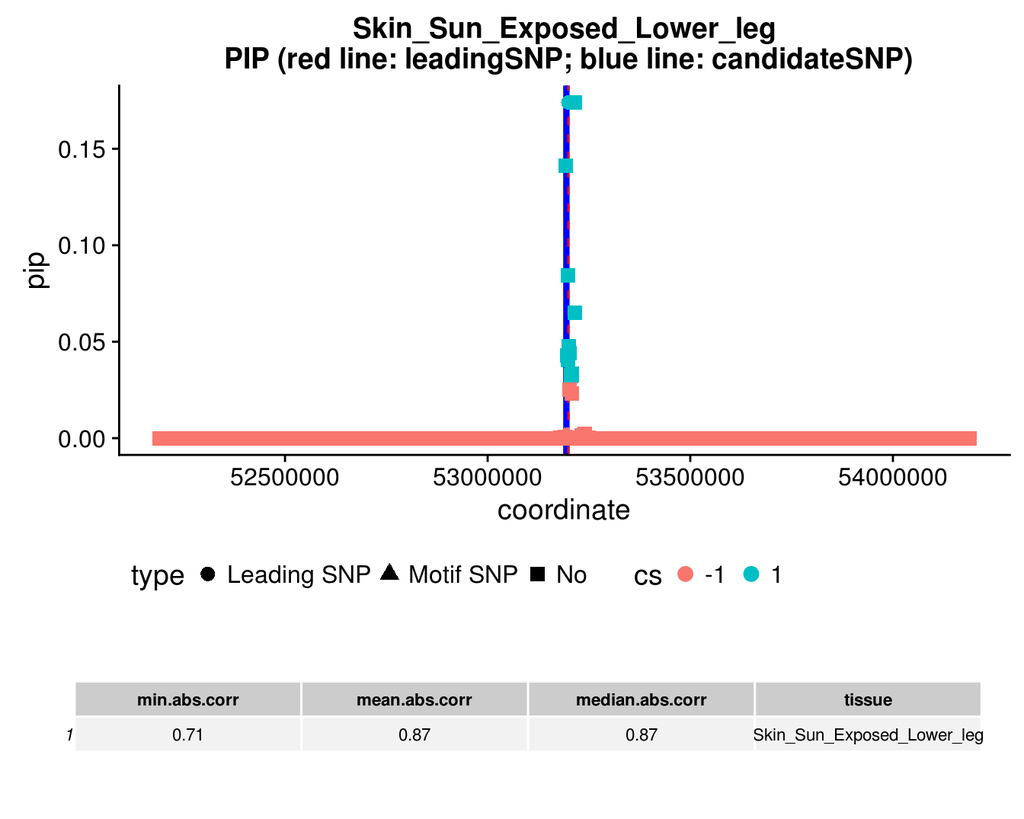

gene_name

motif_snp

r

motif_id

motif_name

motif_qval

motif_snp.pos

motif.length

strand

tissue

pip

motif_logo

5301

PRKCD

3_53199080_C_T_b37

1

GRHL2_HUMAN.H11MO.0.A

NA

0.482

12

12

positive

Skin_Sun_Exposed_Lower_leg

0.1739899

5302

PRKCD

3_53199080_C_T_b37

1

GRHL1_HUMAN.H11MO.0.D

NA

0.515

12

12

positive

Skin_Sun_Exposed_Lower_leg

0.1739899

5303

PRKCD

3_53199080_C_T_b37

1

ZN708_HUMAN.H11MO.0.C

NA

0.291

19

20

negative

Skin_Sun_Exposed_Lower_leg

0.1739899

5304

PRKCD

3_53199080_C_T_b37

1

MAFA_HUMAN.H11MO.0.D

NA

0.167

21

21

negative

Skin_Sun_Exposed_Lower_leg

0.1739899

5305

PRKCD

3_53199080_C_T_b37

1

E2F5_HUMAN.H11MO.0.B

NA

0.689

4

10

negative

Skin_Sun_Exposed_Lower_leg

0.1739899

7988

PRKCD

3_53199080_C_T_b37

1

MA0024.1

E2F1

0.871

6

8

positive

Skin_Sun_Exposed_Lower_leg

0.1739899

## 2.2 Skin_Not_Sum_Exposed_Suprapubic

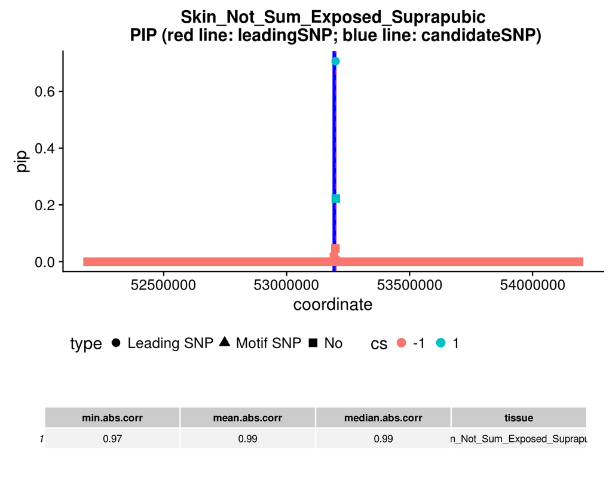

gene_name

motif_snp

r

motif_id

motif_name

motif_qval

motif_snp.pos

motif.length

strand

tissue

pip

motif_logo

1090

PRKCD

3_53199080_C_T_b37

1

GRHL2_HUMAN.H11MO.0.A

NA

0.482

12

12

positive

Skin_Not_Sum_Exposed_Suprapubic

0.70646

1091

PRKCD

3_53199080_C_T_b37

1

GRHL1_HUMAN.H11MO.0.D

NA

0.515

12

12

positive

Skin_Not_Sum_Exposed_Suprapubic

0.70646

1092

PRKCD

3_53199080_C_T_b37

1

ZN708_HUMAN.H11MO.0.C

NA

0.291

19

20

negative

Skin_Not_Sum_Exposed_Suprapubic

0.70646

1093

PRKCD

3_53199080_C_T_b37

1

MAFA_HUMAN.H11MO.0.D

NA

0.167

21

21

negative

Skin_Not_Sum_Exposed_Suprapubic

0.70646

1094

PRKCD

3_53199080_C_T_b37

1

E2F5_HUMAN.H11MO.0.B

NA

0.689

4

10

negative

Skin_Not_Sum_Exposed_Suprapubic

0.70646

3617

PRKCD

3_53199080_C_T_b37

1

MA0024.1

E2F1

0.871

6

8

positive

Skin_Not_Sum_Exposed_Suprapubic

0.70646

## 2.3 Artery_Aorta

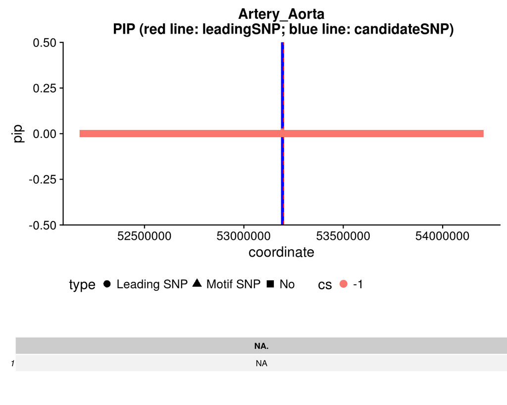

## 2.4 Esophagus_Mucosa

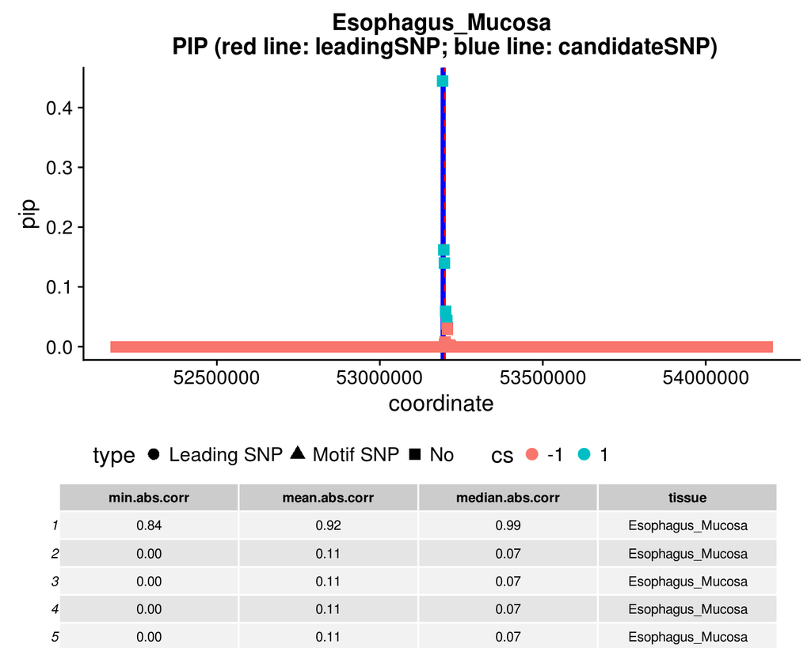

# 3 Summary of SNPs in CS

```r
if(nrow(hitted) != 0) {
  hitted$motif_logo <- paste0('![](', motif_prefix, '/', hitted$dbname, '__', hitted$motif_id, '.png', ')')
  hitted <- hitted[, c(cols, 'motif_logo')]
  hitted %>% kable(format = "html", col.names = colnames(hitted)) %>%
  kable_styling() %>%
  kableExtra::scroll_box(width = "100%", height = "500px")
}
```

gene_name

motif_snp

r

motif_id

motif_name

motif_qval

motif_snp.pos

motif.length

strand

tissue

pip

motif_logo

5301

PRKCD

3_53199080_C_T_b37

1

GRHL2_HUMAN.H11MO.0.A

NA

0.482

12

12

positive

Skin_Sun_Exposed_Lower_leg

0.1739899

5302

PRKCD

3_53199080_C_T_b37

1

GRHL1_HUMAN.H11MO.0.D

NA

0.515

12

12

positive

Skin_Sun_Exposed_Lower_leg

0.1739899

5303

PRKCD

3_53199080_C_T_b37

1

ZN708_HUMAN.H11MO.0.C

NA

0.291

19

20

negative

Skin_Sun_Exposed_Lower_leg

0.1739899

5304

PRKCD

3_53199080_C_T_b37

1

MAFA_HUMAN.H11MO.0.D

NA

0.167

21

21

negative

Skin_Sun_Exposed_Lower_leg

0.1739899

5305

PRKCD

3_53199080_C_T_b37

1

E2F5_HUMAN.H11MO.0.B

NA

0.689

4

10

negative

Skin_Sun_Exposed_Lower_leg

0.1739899

7988

PRKCD

3_53199080_C_T_b37

1

MA0024.1

E2F1

0.871

6

8

positive

Skin_Sun_Exposed_Lower_leg

0.1739899

1090

PRKCD

3_53199080_C_T_b37

1

GRHL2_HUMAN.H11MO.0.A

NA

0.482

12

12

positive

Skin_Not_Sum_Exposed_Suprapubic

0.7064600

1091

PRKCD

3_53199080_C_T_b37

1

GRHL1_HUMAN.H11MO.0.D

NA

0.515

12

12

positive

Skin_Not_Sum_Exposed_Suprapubic

0.7064600

1092

PRKCD

3_53199080_C_T_b37

1

ZN708_HUMAN.H11MO.0.C

NA

0.291

19

20

negative

Skin_Not_Sum_Exposed_Suprapubic

0.7064600

1093

PRKCD

3_53199080_C_T_b37

1

MAFA_HUMAN.H11MO.0.D

NA

0.167

21

21

negative

Skin_Not_Sum_Exposed_Suprapubic

0.7064600

1094

PRKCD

3_53199080_C_T_b37

1

E2F5_HUMAN.H11MO.0.B

NA

0.689

4

10

negative

Skin_Not_Sum_Exposed_Suprapubic

0.7064600

3617

PRKCD

3_53199080_C_T_b37

1

MA0024.1

E2F1

0.871

6

8

positive

Skin_Not_Sum_Exposed_Suprapubic

0.7064600